# R Programming

## filter( )

### Filter values based on defined conditions

## filter( )

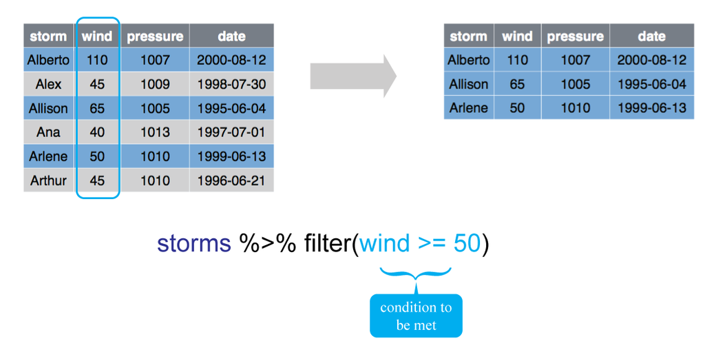

## filter( )

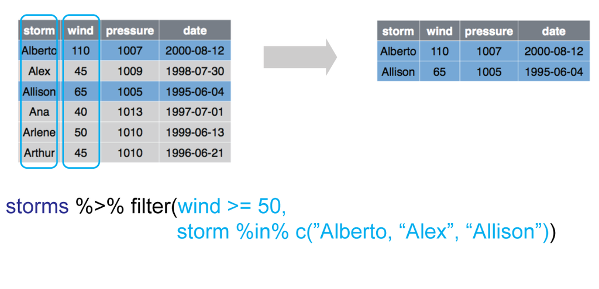

*Can filter for multiple conditions*

## filter( )

We can apply multiple logic rules in the `filter()` function such as:

| < | Less than | != | Not equal to |
| --- | --- | --- | --- |
| > | Greater than | %in% | Group membership |
| == | Equal to | is.na | is NA |
| != | Not equal to | !is.na | is not NA |
| <= | Less than or equal to | &,\|,! | Boolean operators |
| >= | Greater than or equal to |  |  |

## filter( )

Additional subsetting functions:

|  | storms %>% `distinct()` | Remove duplicate rows |
| --- | --- | --- |
|  | storms %>% `sample_frac(0.5, replace = TRUE)` | Randomly select fraction of rows |
|  | storms %>% `sample_n(10, replace = TRUE)` | Randomly select n rows |
|  | storms %>% `slice(3:5)` | Select rows by position |
|  | storms %>% `top_n(storms, 2, date)` | Select and order top n entries |

## Your Turn

Continuing with our `facebook.tsv` data…

> 1. Filter the facebook data for just males

> 2. Select the following variables:

> userid

> age

> gender

> friend_count

> …and then filter for just males

## group_by( )

### Group data by categorical levels

## group_by( )

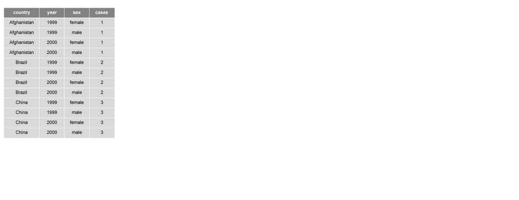

## group_by( )

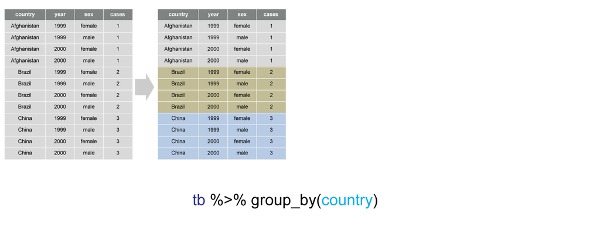

## group_by( )

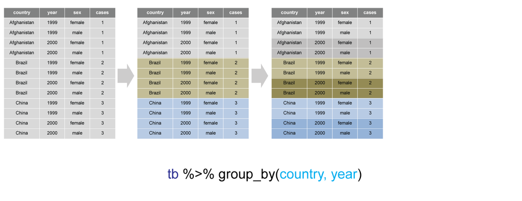

## group_by( )

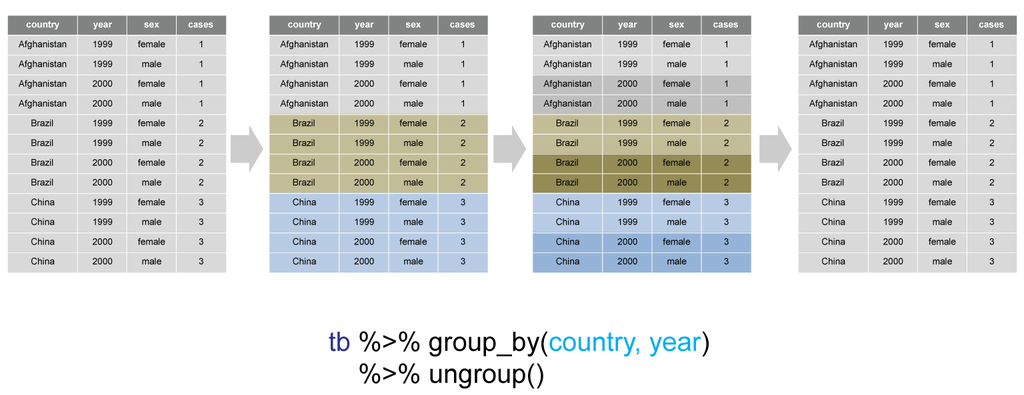

## group_by( )

- `group_by()` function is a *silent* function in which no observable manipulation of the data occurs
- Alters underlying attributes → note Groups: city [3] in output below
- Becomes useful when combined with other functions

```r
pollution %>% group_by(city)
```

```
## Source: local data frame [6 x 3]
## Groups: city [3]
##
##       city  size amount
##      <chr> <chr>  <dbl>
## 1 New York large     23
## 2 New York small     14
## 3   London large     22
## 4   London small     16
## 5  Beijing large    121
## 6  Beijing small     56
```

## Your Turn

Continuing with our `facebook.tsv` data…

> Select the following variables:

> userid

> age

> gender

> friend_count

> …and then group by gender

## summarise( )

### Change unit of analysis

## summarise( )

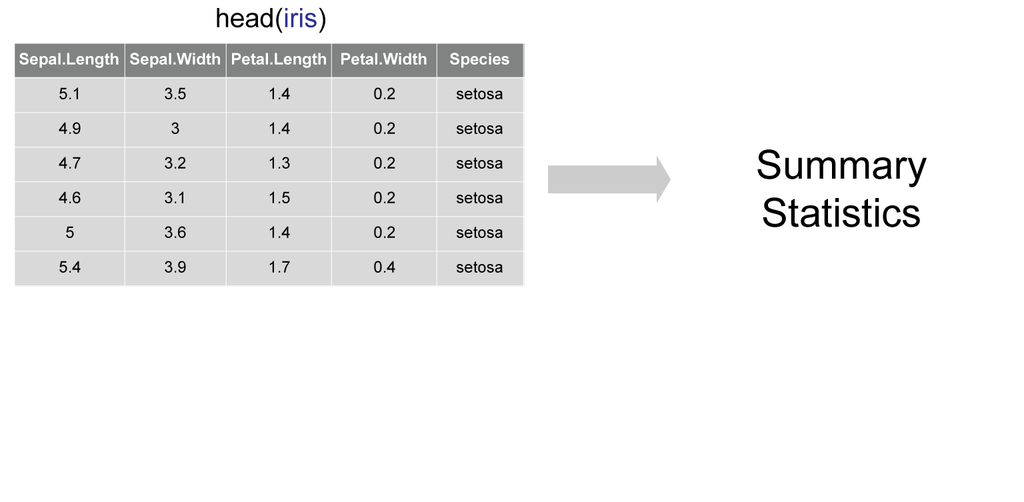

## summarise( )

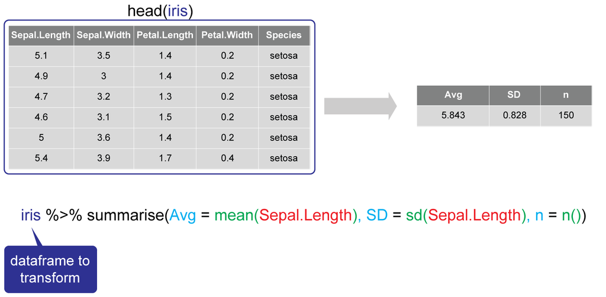

## summarise( )

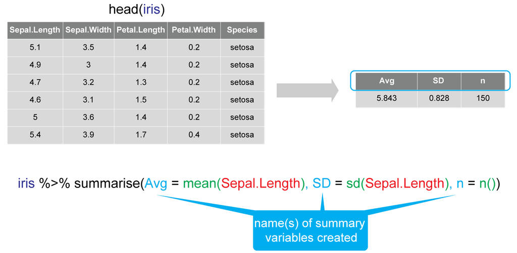

## summarise( )

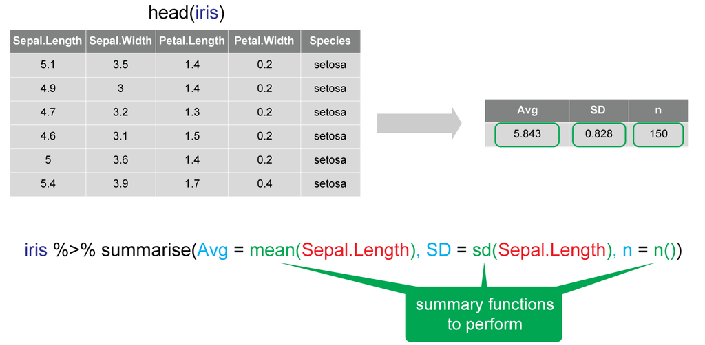

## summarise( )

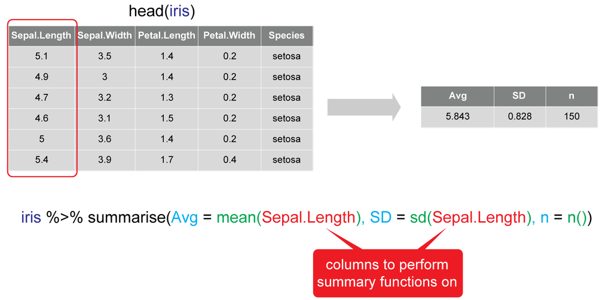

## summarise( )

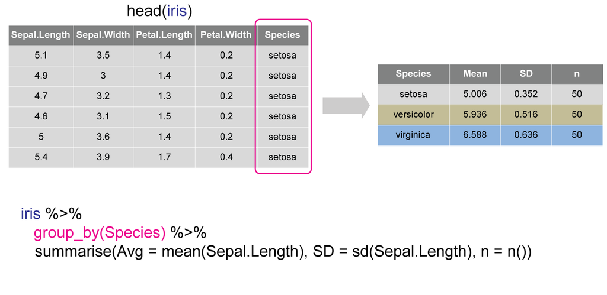

## summarise( )

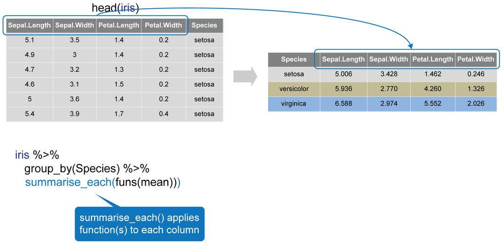

## summarise( )

Summary functions:

|  | `first()` | First value of a vector | `min()` | Min value in vector |
| --- | --- | --- | --- | --- |
|  | `last()` | Last value of a vector | `max()` | Max value in vector |
|  | `nth()` | Nth value of a vector | `mean()` | Mean value of vector |
|  | `n()` | # of values in a vector | `median()` | Median value of vector |
|  | `n_distinct()` | # of distinct values | `var()` | Variance of vector |
|  | `IQR()` | IQR of a vector | `sd()` | St. dev. of vector |

## Your Turn

Continuing with our `facebook.tsv` data…

> 1. Calculate the mean and median for `tenure` and `friend_count`

> 2. Select the following variables:

> gender

> age

> friend_count

> group by gender and calculate the mean and median for `age` and `friend_count`

## arrange( )

### Order data

## arrange( )

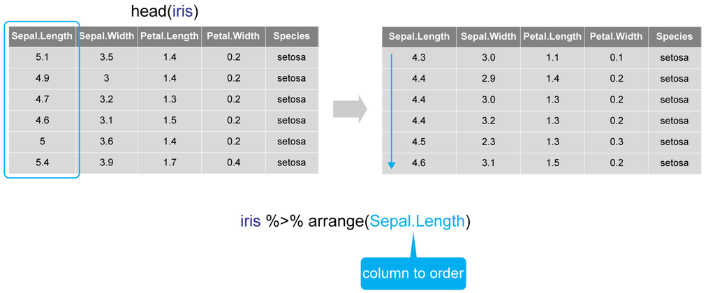

## arrange( )

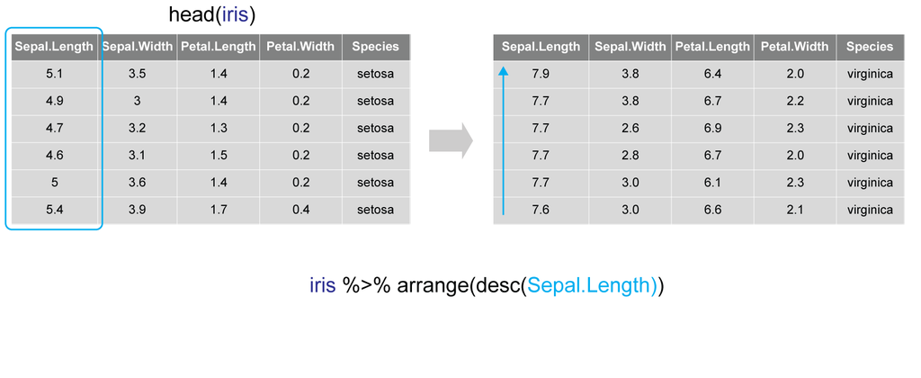

*Use `desc(x)` to sort variable(s) in descending order*

## Your Turn

Continuing with our `facebook.tsv` data…

> 1. Group the data by `age`

> 2. Calculate the median `friend_count` for each age

> 3. Arrange the median calculated `friend_count` variable in descending order to find the ages with the greatest median friend count

## mutate( )

### Create new variables

## mutate( )

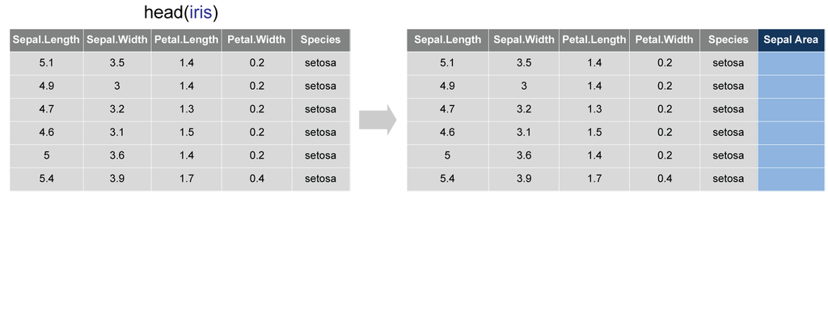

## mutate( )

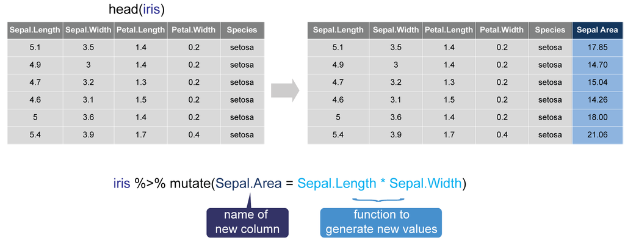

## mutate( )

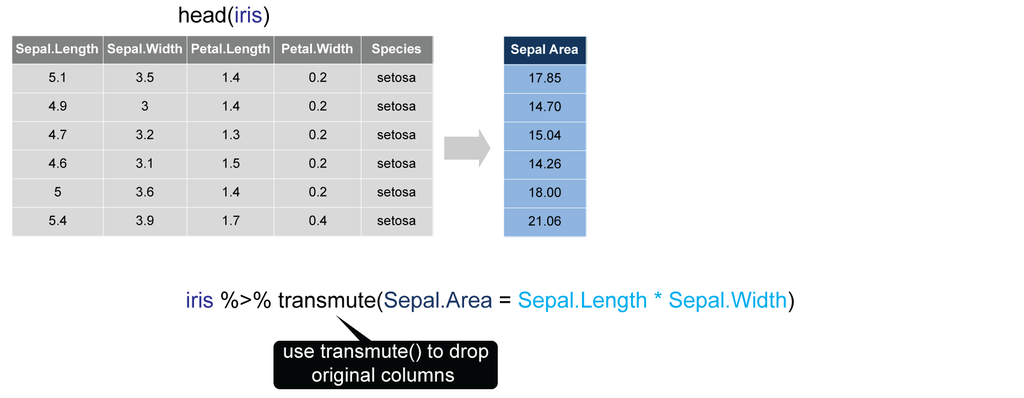

## mutate( )

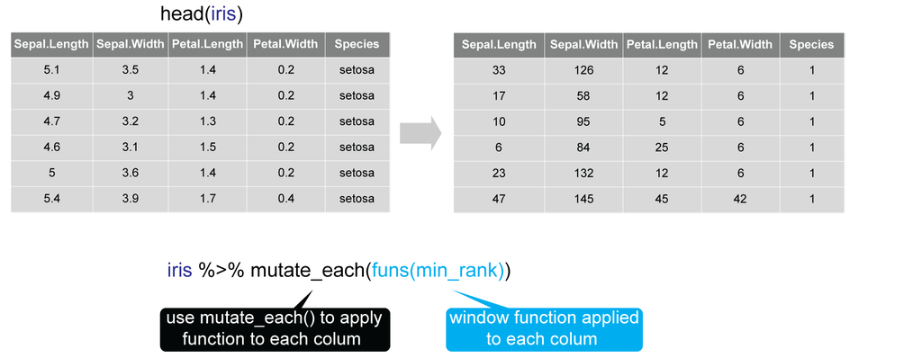

## mutate( )

Window functions that can be applied within `mutate_each(funs())`:

|  | `lead()` | `ntile()` | `cumsum()` |
| --- | --- | --- | --- |
|  | `lag()` | `between()` | `cummax()` |
|  | `dense_rank()` | `cume_dist()` | `cummin()` |
|  | `min_rank()` | `cumall()` | `cumprod()` |
|  | `percent_rank()` | `cumany()` | `pmax()` |
|  | `row_number()` | `cumean()` | `pmin()` |

- Can also create own functions to pass through `mutate_each(funs())`
- Be aware that some functions will cause errors when applied to non-numeric variables

## Your Turn

Continuing with our `facebook.tsv` data…

> 1. Create a new variable `friend_ratio` that equals

> \[\text{friend_ratio} = \frac{\text{friendships_initiated}}{\text{friend_count}}\]

> 2. Find the median `friend_ratio` for males and females.

## join( )

### Combine separate data sets

## join( )

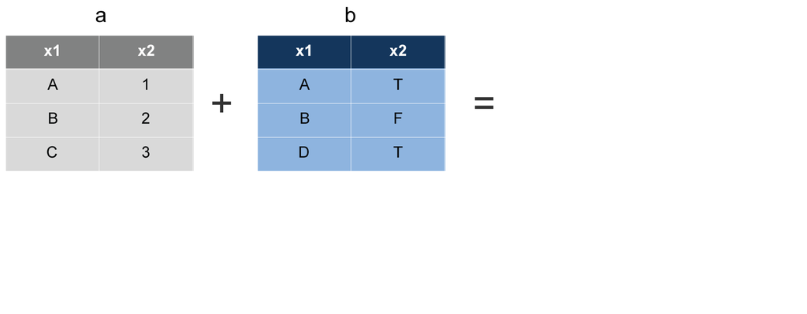

## join( )

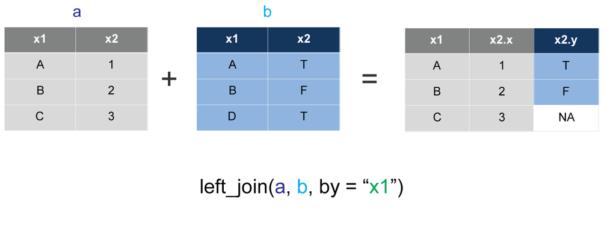

*Join matching rows from `b` to `a`*

## join( )

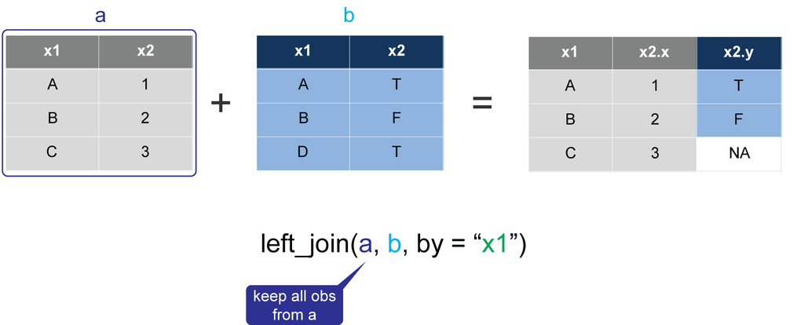

*Join matching rows from `b` to `a`*

## join( )

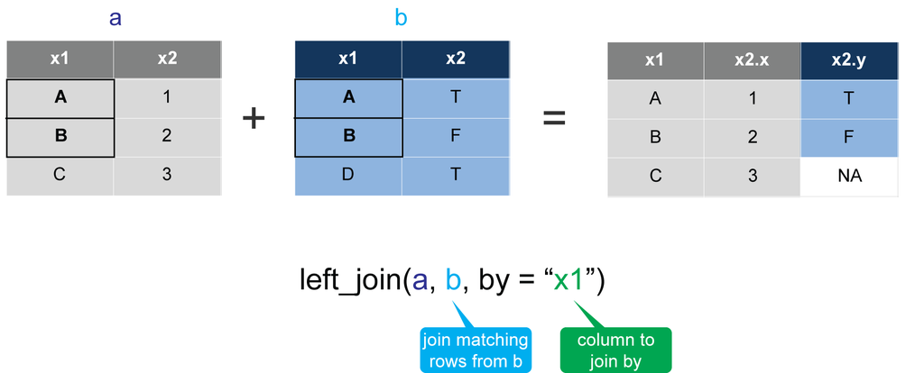

*Join matching rows from `b` to `a`*

## join( )

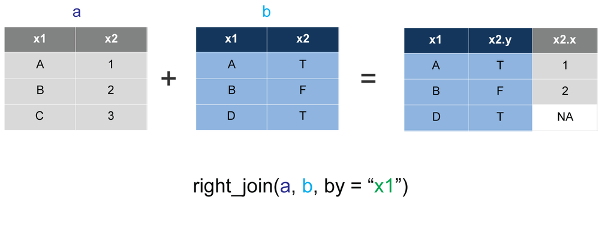

*Join matching rows from `a` to `b`*

## join( )

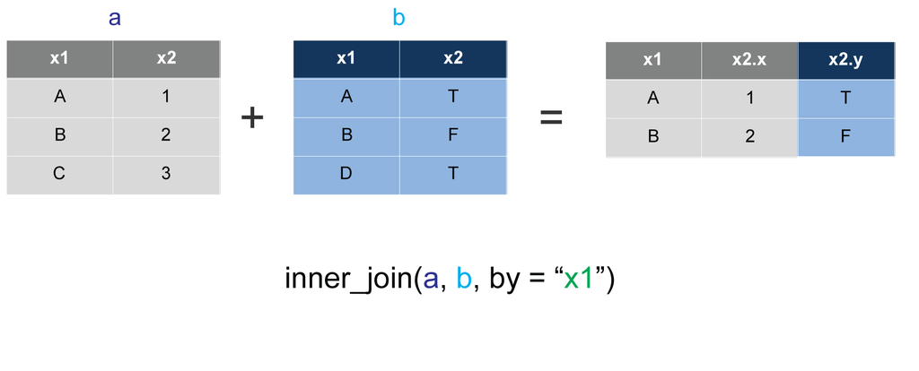

*Join data. Retain only matching rows in both sets.*